# unified

## Setup & Data Transformations

Single source of truth for the data, feature columns, targets, model hyperparameters, CV splitter, and bootstrap bookkeeping reused by every section.

```
n_samples=6768, n_features=84, n_proteins=376, enriched_rate=0.391
```

```
n_NPs=18
```

## Helpers

Reusable functions shared across sections: cluster-bootstrap importances, importance summary + top-K plot, RFECV 1-SD summary + curve, out-of-fold classifier metrics, and the PDP/ICE grid. Dedicated RNGs keep the bootstrap resampling and the ICE row-subsample reproducible regardless of run order.

## RFR. Bootstrap Feature Importance

Cluster-bootstrap (resample protein groups, N=500) Gini importances for the abundance regressor (`log1p` target) on the full feature set, with 95% percentile CIs, followed by a Spearman correlation heatmap of the top-10 features.

|  | importance |
| --- | --- |
| abundance_controls | 0.673807 |
| zeta_potential | 0.023262 |
| nsp_secondary_structure_coil | 0.019349 |
| nsp_secondary_structure_helix | 0.017753 |
| dh_functionalized | 0.014771 |
| frac_aa_r | 0.010341 |
| incubation_concentration_mg_per_ml | 0.007904 |
| frac_aa_n | 0.007472 |
| frac_aa_m | 0.006636 |
| fraction_exposed_exposed_c | 0.006628 |
| fraction_exposed_exposed_y | 0.006614 |
| fraction_exposed_exposed_r | 0.006537 |
| ligand_pei | 0.006479 |
| rsa_std | 0.006475 |
| fraction_exposed_exposed_w | 0.006189 |
| dtem | 0.006034 |
| fraction_exposed_exposed_a | 0.005709 |
| frac_aa_h | 0.005621 |
| fraction_exposed_exposed_n | 0.005578 |
| instability_index | 0.005396 |

```
  bootstrap 100/500
```

```
  bootstrap 200/500
```

```
  bootstrap 300/500
```

```
  bootstrap 400/500
```

```
  bootstrap 500/500
```

|  | observed | boot_mean | ci_low | ci_high |
| --- | --- | --- | --- | --- |
| abundance_controls | 0.673807 | 0.623588 | 0.389254 | 0.815087 |
| zeta_potential | 0.023262 | 0.029907 | 0.013111 | 0.058983 |
| nsp_secondary_structure_coil | 0.019349 | 0.004718 | 0.000529 | 0.022222 |
| nsp_secondary_structure_helix | 0.017753 | 0.005620 | 0.000619 | 0.026200 |
| dh_functionalized | 0.014771 | 0.015168 | 0.009831 | 0.022348 |
| frac_aa_r | 0.010341 | 0.006286 | 0.000569 | 0.033743 |
| incubation_concentration_mg_per_ml | 0.007904 | 0.011806 | 0.005196 | 0.020938 |
| frac_aa_n | 0.007472 | 0.004514 | 0.000676 | 0.019298 |
| frac_aa_m | 0.006636 | 0.004935 | 0.000675 | 0.020398 |
| fraction_exposed_exposed_c | 0.006628 | 0.003603 | 0.000668 | 0.013291 |
| fraction_exposed_exposed_y | 0.006614 | 0.004111 | 0.000567 | 0.018478 |
| fraction_exposed_exposed_r | 0.006537 | 0.006095 | 0.000854 | 0.026479 |
| ligand_pei | 0.006479 | 0.008223 | 0.002212 | 0.018475 |
| rsa_std | 0.006475 | 0.003089 | 0.000502 | 0.012595 |
| fraction_exposed_exposed_w | 0.006189 | 0.003325 | 0.000415 | 0.014156 |
| dtem | 0.006034 | 0.006720 | 0.002959 | 0.012811 |
| fraction_exposed_exposed_a | 0.005709 | 0.003717 | 0.000535 | 0.012859 |
| frac_aa_h | 0.005621 | 0.003696 | 0.000632 | 0.014186 |
| fraction_exposed_exposed_n | 0.005578 | 0.003524 | 0.000589 | 0.016548 |
| instability_index | 0.005396 | 0.004103 | 0.000647 | 0.015471 |

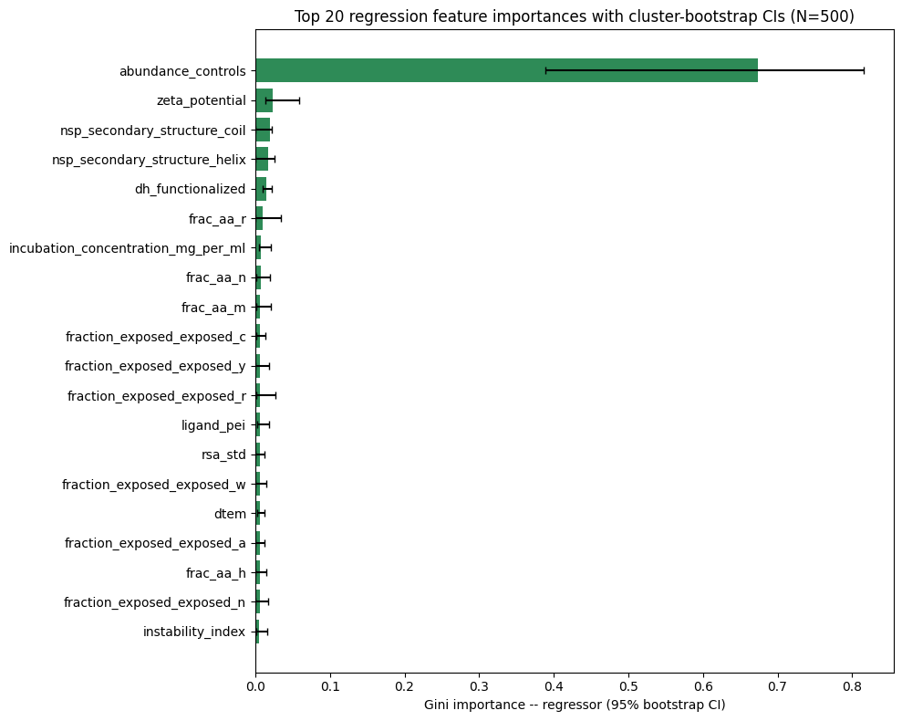

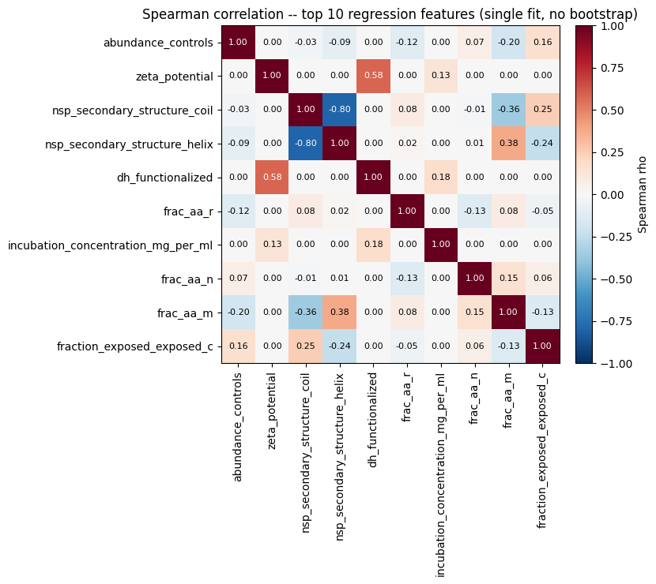

|  | abundance_controls | zeta_potential | nsp_secondary_structure_coil | nsp_secondary_structure_helix | dh_functionalized | frac_aa_r | incubation_concentration_mg_per_ml | frac_aa_n | frac_aa_m | fraction_exposed_exposed_c |
| --- | --- | --- | --- | --- | --- | --- | --- | --- | --- | --- |
| abundance_controls | 1.000 | 0.000 | -0.026 | -0.091 | 0.000 | -0.125 | 0.000 | 0.069 | -0.195 | 0.162 |
| zeta_potential | 0.000 | 1.000 | 0.000 | 0.000 | 0.581 | 0.000 | 0.132 | 0.000 | 0.000 | 0.000 |
| nsp_secondary_structure_coil | -0.026 | 0.000 | 1.000 | -0.803 | 0.000 | 0.085 | 0.000 | -0.009 | -0.359 | 0.246 |
| nsp_secondary_structure_helix | -0.091 | 0.000 | -0.803 | 1.000 | 0.000 | 0.020 | 0.000 | 0.008 | 0.377 | -0.237 |
| dh_functionalized | 0.000 | 0.581 | 0.000 | 0.000 | 1.000 | 0.000 | 0.176 | 0.000 | 0.000 | 0.000 |
| frac_aa_r | -0.125 | 0.000 | 0.085 | 0.020 | 0.000 | 1.000 | 0.000 | -0.131 | 0.083 | -0.049 |
| incubation_concentration_mg_per_ml | 0.000 | 0.132 | 0.000 | 0.000 | 0.176 | 0.000 | 1.000 | 0.000 | 0.000 | 0.000 |
| frac_aa_n | 0.069 | 0.000 | -0.009 | 0.008 | 0.000 | -0.131 | 0.000 | 1.000 | 0.151 | 0.055 |
| frac_aa_m | -0.195 | 0.000 | -0.359 | 0.377 | 0.000 | 0.083 | 0.000 | 0.151 | 1.000 | -0.135 |
| fraction_exposed_exposed_c | 0.162 | 0.000 | 0.246 | -0.237 | 0.000 | -0.049 | 0.000 | 0.055 | -0.135 | 1.000 |

## RFC. Bootstrap Feature Importance

Cluster-bootstrap (N=500) Gini importances for the enrichment classifier on the full feature set, with 95% percentile CIs.

|  | importance |
| --- | --- |
| zeta_potential | 0.047076 |
| abundance_controls | 0.029204 |
| dh_functionalized | 0.025261 |
| secondary_structure_fraction_sheet | 0.023959 |
| ligand_pei | 0.023577 |
| dtem | 0.017426 |
| frac_aa_a | 0.015359 |
| fraction_exposed | 0.015216 |
| nsp_secondary_structure_helix | 0.015149 |
| frac_aa_c | 0.014838 |
| frac_aa_r | 0.014256 |
| fraction_exposed_exposed_k | 0.014164 |
| fraction_exposed_exposed_v | 0.013887 |
| fraction_exposed_nonpolar_total | 0.013630 |
| asa_sum | 0.013364 |
| fraction_exposed_exposed_l | 0.013343 |
| fraction_exposed_exposed_r | 0.012973 |
| frac_aa_i | 0.012932 |
| frac_aa_p | 0.012927 |
| frac_aa_s | 0.012519 |

```
  bootstrap 100/500
```

```
  bootstrap 200/500
```

```
  bootstrap 300/500
```

```
  bootstrap 400/500
```

```
  bootstrap 500/500
```

|  | observed | boot_mean | ci_low | ci_high |
| --- | --- | --- | --- | --- |
| zeta_potential | 0.047076 | 0.060530 | 0.052501 | 0.068012 |
| abundance_controls | 0.029204 | 0.020766 | 0.008532 | 0.037825 |
| dh_functionalized | 0.025261 | 0.034230 | 0.029482 | 0.038765 |
| secondary_structure_fraction_sheet | 0.023959 | 0.019962 | 0.010317 | 0.032694 |
| ligand_pei | 0.023577 | 0.032976 | 0.026917 | 0.039062 |
| dtem | 0.017426 | 0.022291 | 0.018826 | 0.026222 |
| frac_aa_a | 0.015359 | 0.015678 | 0.008761 | 0.028115 |
| fraction_exposed | 0.015216 | 0.011767 | 0.007588 | 0.018623 |
| nsp_secondary_structure_helix | 0.015149 | 0.012868 | 0.008362 | 0.020656 |
| frac_aa_c | 0.014838 | 0.012484 | 0.007710 | 0.020867 |
| frac_aa_r | 0.014256 | 0.013076 | 0.007913 | 0.022593 |
| fraction_exposed_exposed_k | 0.014164 | 0.012128 | 0.008032 | 0.019321 |
| fraction_exposed_exposed_v | 0.013887 | 0.012424 | 0.008004 | 0.021353 |
| fraction_exposed_nonpolar_total | 0.013630 | 0.009493 | 0.006665 | 0.013547 |
| asa_sum | 0.013364 | 0.012738 | 0.008016 | 0.020746 |
| fraction_exposed_exposed_l | 0.013343 | 0.012166 | 0.008249 | 0.018096 |
| fraction_exposed_exposed_r | 0.012973 | 0.011382 | 0.007789 | 0.017592 |
| frac_aa_i | 0.012932 | 0.011510 | 0.007579 | 0.018526 |
| frac_aa_p | 0.012927 | 0.009861 | 0.007138 | 0.013930 |
| frac_aa_s | 0.012519 | 0.011298 | 0.007468 | 0.018291 |

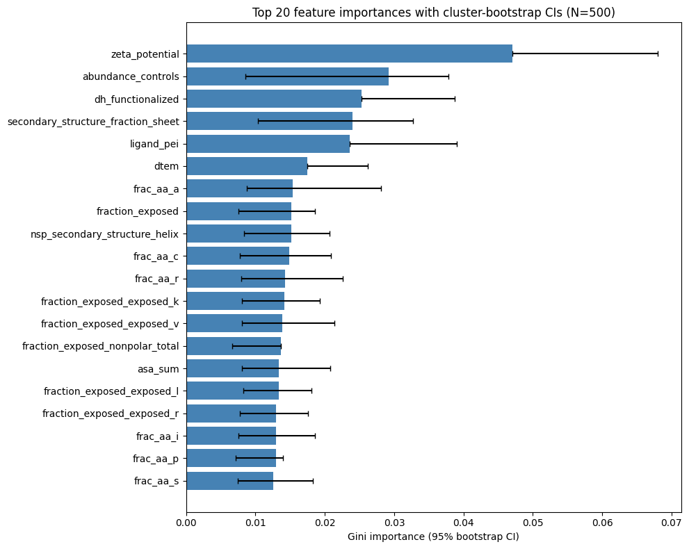

## SHAP Beeswarm. Regression on Full Data

TreeSHAP for the RF regressor refit on the full dataset under each of the three abundance transforms. Beeswarm of the top-20 features per transform.

```
      log1p: in-sample R^2 = 0.8984
```

```
      asinh: in-sample R^2 = 0.8945
```

```
 log2_floor: in-sample R^2 = 0.8781
```

```
      log1p: SHAP shape (6768, 84), base = 0.0947
```

```
      asinh: SHAP shape (6768, 84), base = 0.1163
```

```
 log2_floor: SHAP shape (6768, 84), base = -9.0140
```

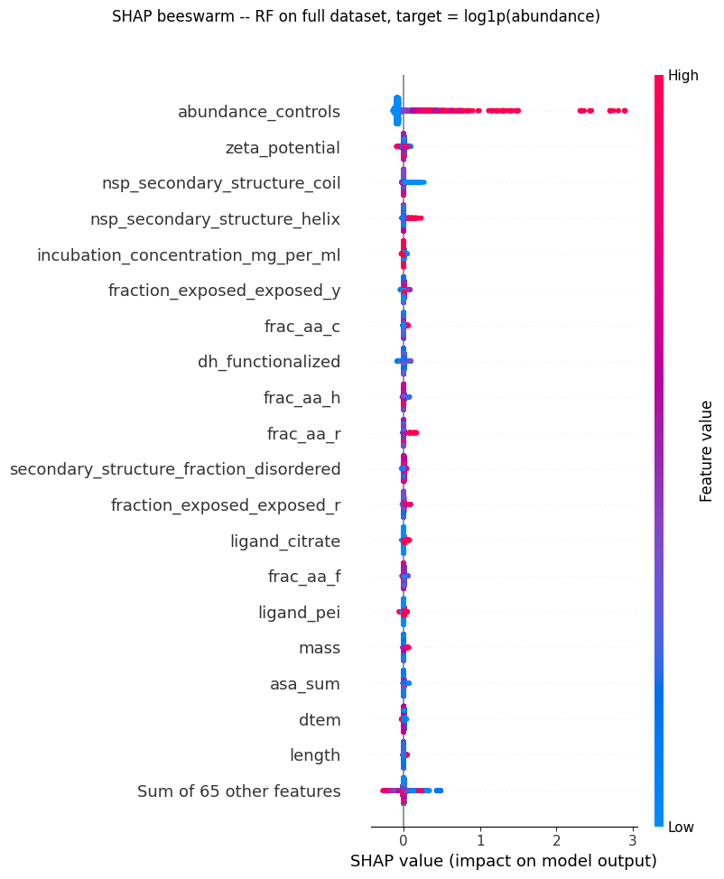

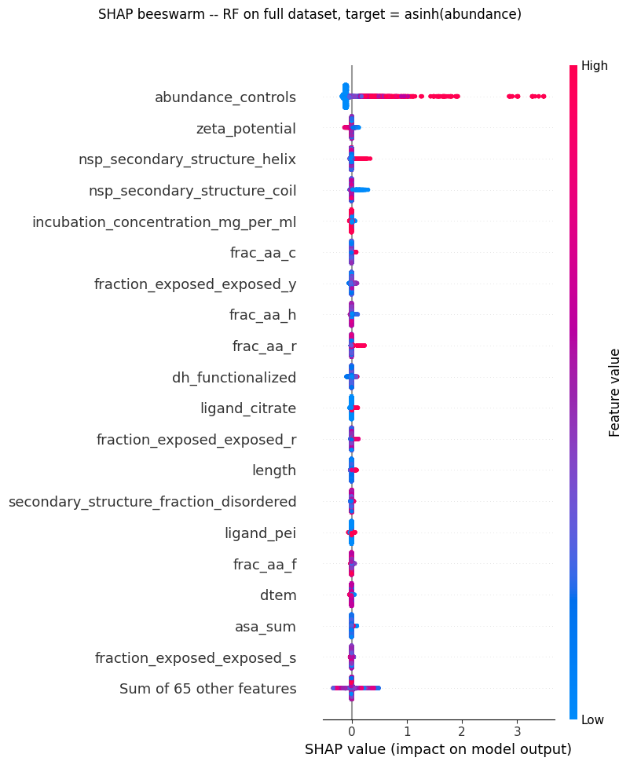

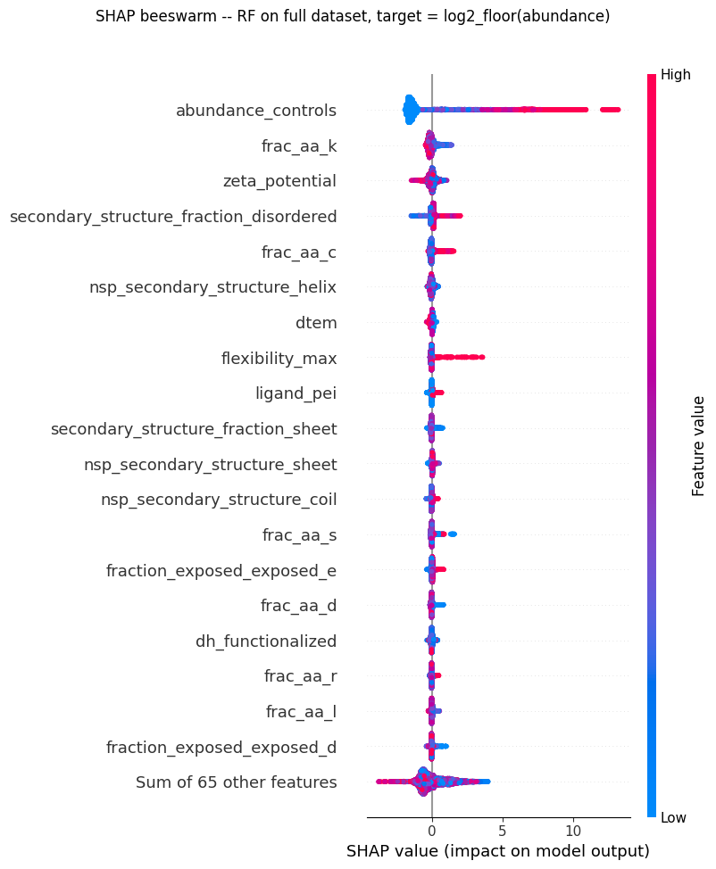

## RFECV. Abundance Regressor

Recursive feature elimination with GroupKFold-5 by NP, scoring negative MAE in `log1p` space. Marks the min-MAE K and the 1-SD parsimonious K.

```
reg RFECV selected K: 77 / 84
min-MAE K:            77  (CV MAE 0.0482 +/- 0.0080, log1p space)
1-SD parsimonious K:  3  (CV MAE 0.0561)
full-set CV MAE:      0.0484 +/- 0.0081
```

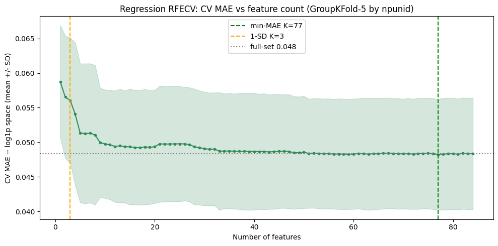

```
Regression-selected parsimonious features:
  abundance_controls
  zeta_potential
  nsp_secondary_structure_coil
```

**CV-grouping note (NP vs protein).** This RFECV groups folds by NP (`npunid`), matching the leave-one-NP-out evaluation further below. Re-running it grouped by protein (`entry`) changes the result substantially: min-MAE rises from ~0.048 to ~0.088 (log1p) and the survivor set collapses from 77 to 7 features (those 7 are a subset of the 77).

## Permutation Importance (OOF). Classifier

Out-of-fold permutation importance (GroupKFold by protein, ROC AUC) for the enrichment classifier. Used to order the RFECV-selected features below.

```
  fold 1/10
```

```
  fold 2/10
```

```
  fold 3/10
```

```
  fold 4/10
```

```
  fold 5/10
```

```
  fold 6/10
```

```
  fold 7/10
```

```
  fold 8/10
```

```
  fold 9/10
```

```
  fold 10/10
```

```
(100, 84)
```

|  | mean | std | ci_low | ci_high |
| --- | --- | --- | --- | --- |
| abundance_controls | 0.020325 | 0.021942 | -0.026879 | 0.059574 |
| secondary_structure_fraction_sheet | 0.018602 | 0.013412 | 0.000068 | 0.050434 |
| zeta_potential | 0.016832 | 0.009143 | -0.000713 | 0.031602 |
| ligand_pei | 0.010875 | 0.006177 | -0.000341 | 0.025221 |
| nsp_secondary_structure_coil | 0.008409 | 0.007646 | -0.004557 | 0.024298 |
| fraction_exposed_exposed_k | 0.007823 | 0.008030 | -0.010678 | 0.020358 |
| frac_aa_a | 0.005911 | 0.010554 | -0.008041 | 0.031108 |
| frac_aa_c | 0.005665 | 0.005571 | -0.002015 | 0.018461 |
| dtem | 0.005287 | 0.003092 | -0.001018 | 0.010311 |
| frac_aa_r | 0.005214 | 0.010479 | -0.009933 | 0.032097 |
| dh_functionalized | 0.005027 | 0.003727 | -0.000337 | 0.014656 |
| fraction_buried | 0.003920 | 0.006473 | -0.009668 | 0.014472 |
| fraction_exposed | 0.003845 | 0.005665 | -0.006338 | 0.015992 |
| fraction_exposed_exposed_y | 0.003834 | 0.003401 | -0.002498 | 0.010276 |
| nsp_secondary_structure_sheet | 0.003324 | 0.006718 | -0.014400 | 0.013466 |
| isoelectric_point | 0.003165 | 0.003261 | -0.003106 | 0.007949 |
| frac_aa_k | 0.003153 | 0.005850 | -0.005734 | 0.015836 |
| fraction_exposed_exposed_l | 0.002987 | 0.005110 | -0.007459 | 0.014308 |
| fraction_exposed_exposed_e | 0.002916 | 0.003912 | -0.003380 | 0.011728 |
| molecular_weight | 0.002907 | 0.005199 | -0.005166 | 0.015325 |

## RFECV. Enrichment classifier (7-feature parsimonious set)

Recursive feature elimination with GroupKFold by protein, scoring ROC AUC. The 1-SD parsimonious criterion selects 7 features (= `PARSI_7`). Ties among RFECV survivors are broken by permutation-importance rank.

```
RFECV selected K:    26 / 84
max-AUC K:           26   (CV AUC 0.6975 +/- 0.0544)
1-SD parsimonious K: 7   (CV AUC 0.6448)
full-set CV AUC:     0.6811 +/- 0.0471
```

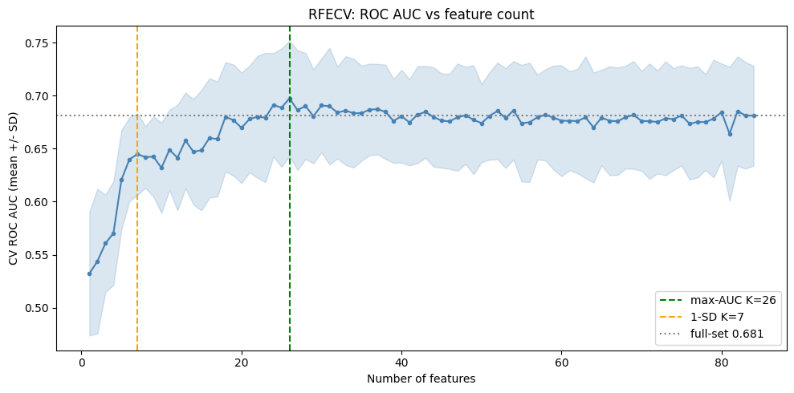

```
26 features kept by RFECV (max-AUC criterion):
```

|  | perm_rank | perm_mean |
| --- | --- | --- |
| abundance_controls | 1 | 0.020325 |
| secondary_structure_fraction_sheet | 2 | 0.018602 |
| zeta_potential | 3 | 0.016832 |
| ligand_pei | 4 | 0.010875 |
| nsp_secondary_structure_coil | 5 | 0.008409 |
| fraction_exposed_exposed_k | 6 | 0.007823 |
| frac_aa_a | 7 | 0.005911 |
| frac_aa_c | 8 | 0.005665 |
| frac_aa_r | 10 | 0.005214 |
| dh_functionalized | 11 | 0.005027 |
| fraction_buried | 12 | 0.003920 |
| fraction_exposed | 13 | 0.003845 |
| isoelectric_point | 16 | 0.003165 |
| fraction_exposed_exposed_l | 18 | 0.002987 |
| fraction_exposed_exposed_e | 19 | 0.002916 |
| nsp_secondary_structure_helix | 25 | 0.002394 |
| asa_sum | 32 | 0.001546 |
| fraction_exposed_exposed_s | 34 | 0.001397 |
| frac_aa_s | 36 | 0.001290 |
| fraction_exposed_exposed_p | 49 | 0.000812 |
| length | 53 | 0.000682 |
| fraction_exposed_polar_exposed | 63 | 0.000149 |
| flexibility_min | 71 | -0.000427 |
| fraction_exposed_exposed_f | 72 | -0.000455 |
| flexibility_max | 74 | -0.000737 |
| fraction_exposed_exposed_v | 80 | -0.001647 |

```
               K  roc_auc  accuracy  balanced_accuracy  precision  recall  \
set
full          84   0.6769    0.6556             0.5883     0.6350  0.2800
rfecv         26   0.7131    0.6871             0.6305     0.6838  0.3711
parsimonious   7   0.6743    0.6649             0.6164     0.6107  0.3942

                  f1
set
full          0.3887
rfecv         0.4811
parsimonious  0.4791

Parsimonious feature set:
  abundance_controls
  secondary_structure_fraction_sheet
  zeta_potential
  ligand_pei
  nsp_secondary_structure_coil
  fraction_exposed_exposed_k
  frac_aa_a
```

**CV-grouping note (protein vs NP).** This RFECV groups folds by protein (`entry`). Re-running it grouped by NP (`npunid`) instead inflates CV ROC AUC from ~0.70 to ~0.86 and shrinks the survivor set from 26 to 9 features (dropping 3 of the 7 `PARSI_7` features). That jump is leakage. Leaving protein-based grouping.

## Parsimonious Model. 6 Features

Enrichment classifier and abundance regressor on `PARSI_6`, each with PDP/ICE and SHAP, followed by protein response-curve clustering. The 7-feature set is kept as a reference to confirm dropping the collinear `ligand_pei` costs nothing.

```
Spearman(zeta_potential, ligand_pei) = 0.821  (p=0.00e+00)

6-feature parsimonious set:
  abundance_controls
  secondary_structure_fraction_sheet
  zeta_potential
  nsp_secondary_structure_coil
  fraction_exposed_exposed_k
  frac_aa_a

Spearman correlation among the 6 features:
```

|  | abundance_controls | secondary_structure_fraction_sheet | zeta_potential | nsp_secondary_structure_coil | fraction_exposed_exposed_k | frac_aa_a |
| --- | --- | --- | --- | --- | --- | --- |
| abundance_controls | 1.000 | -0.018 | 0.0 | -0.026 | -0.063 | -0.052 |
| secondary_structure_fraction_sheet | -0.018 | 1.000 | 0.0 | -0.484 | 0.155 | 0.594 |
| zeta_potential | 0.000 | 0.000 | 1.0 | 0.000 | 0.000 | 0.000 |
| nsp_secondary_structure_coil | -0.026 | -0.484 | 0.0 | 1.000 | -0.428 | -0.313 |
| fraction_exposed_exposed_k | -0.063 | 0.155 | 0.0 | -0.428 | 1.000 | -0.035 |
| frac_aa_a | -0.052 | 0.594 | 0.0 | -0.313 | -0.035 | 1.000 |

### Enrichment / Depletion Classifier

```
          K  roc_auc  accuracy  balanced_accuracy  precision  recall      f1
set
full_84  84   0.6769    0.6556             0.5883     0.6350  0.2800  0.3887
parsi_7   7   0.6743    0.6649             0.6164     0.6107  0.3942  0.4791
parsi_6   6   0.6683    0.6597             0.6119     0.5988  0.3927  0.4743
```

```
Classification report -- 6-feature model (out-of-fold):
              precision    recall  f1-score   support

    depleted      0.681     0.831     0.748      4122
    enriched      0.599     0.393     0.474      2646

    accuracy                          0.660      6768
   macro avg      0.640     0.612     0.611      6768
weighted avg      0.649     0.660     0.641      6768
```

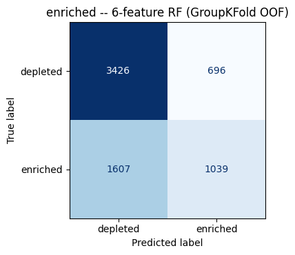

### PDP + ICE. Classifier

Classifier refit on all rows with the 6 features. Each panel shows the blue PDP (average effect) over a thin ICE sample; y axis is partial dependence of P(enriched).

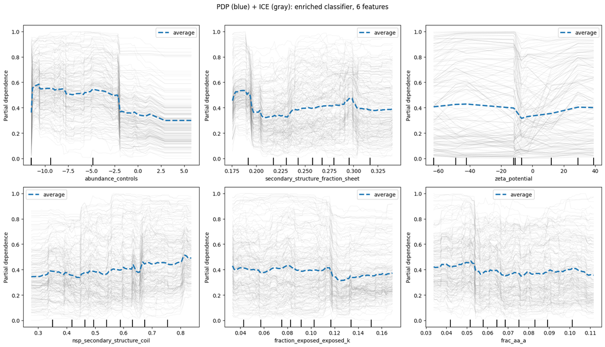

### SHAP. Classifier

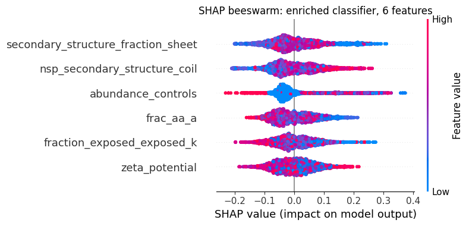

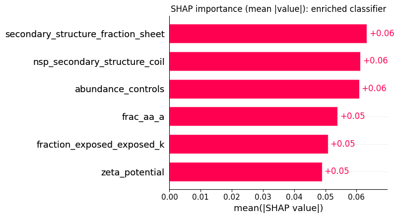

### Abundance Regressor: 3 Transforms

True leave-one-NP-out (18 folds). Metrics reported both in the transformed target space (`*_t`) and back in raw abundance space (`*_raw`).

| set | transform | K | r2_t | mae_t | r2_raw | mae_raw | rmse_raw | spearman_raw |
| --- | --- | --- | --- | --- | --- | --- | --- | --- |
| full_84 | log1p | 84 | 0.8305 | 0.0447 | 0.8091 | 0.1280 | 0.8564 | 0.7415 |
|  | asinh | 84 | 0.8245 | 0.0557 | 0.8083 | 0.1287 | 0.8583 | 0.7360 |
|  | log2_floor | 84 | 0.7810 | 1.4666 | 0.7962 | 0.1257 | 0.8849 | 0.7913 |
| parsi_7 | log1p | 7 | 0.8281 | 0.0453 | 0.7890 | 0.1350 | 0.9004 | 0.7470 |
|  | asinh | 7 | 0.8223 | 0.0565 | 0.7877 | 0.1358 | 0.9032 | 0.7447 |
|  | log2_floor | 7 | 0.7727 | 1.4643 | 0.7782 | 0.1322 | 0.9232 | 0.7870 |
| parsi_6 | log1p | 6 | 0.8280 | 0.0453 | 0.7889 | 0.1350 | 0.9006 | 0.7470 |
|  | asinh | 6 | 0.8222 | 0.0565 | 0.7877 | 0.1358 | 0.9033 | 0.7447 |
|  | log2_floor | 6 | 0.7727 | 1.4646 | 0.7781 | 0.1322 | 0.9235 | 0.7869 |

### PDP + ICE. Regression

One PDP/ICE grid per transform, regressor refit on all rows. Y axis is partial dependence of the predicted target in transformed space.

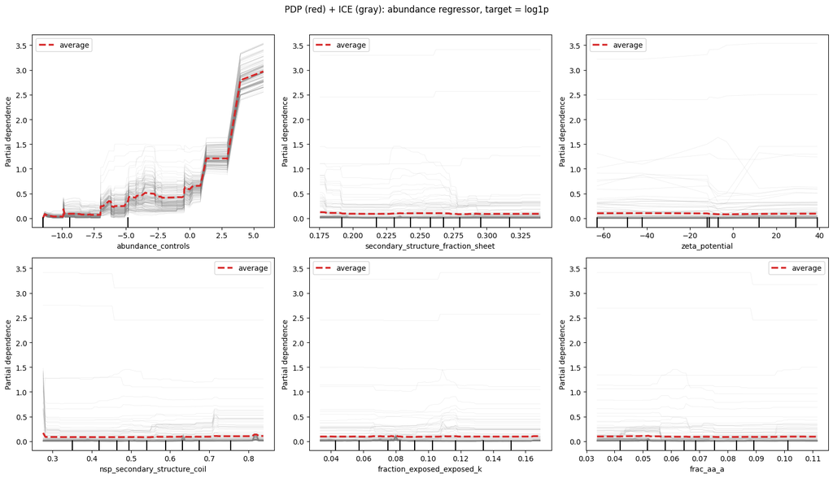

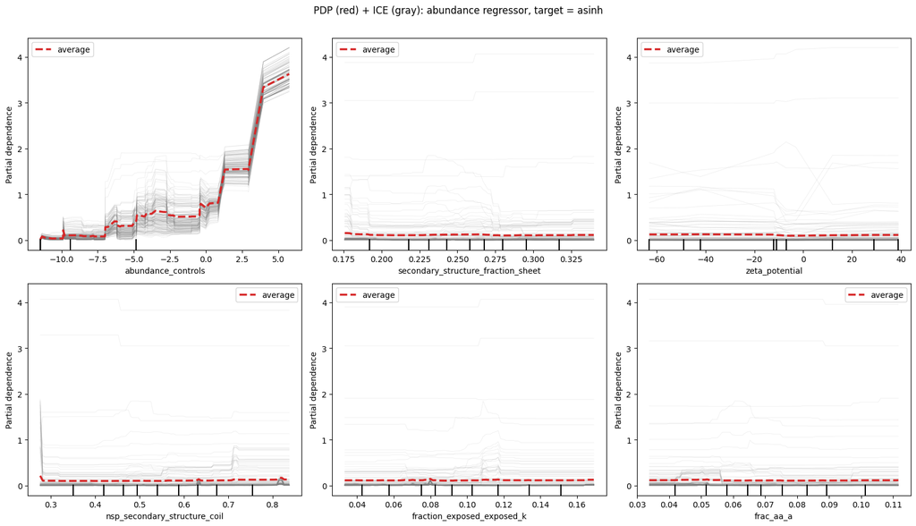

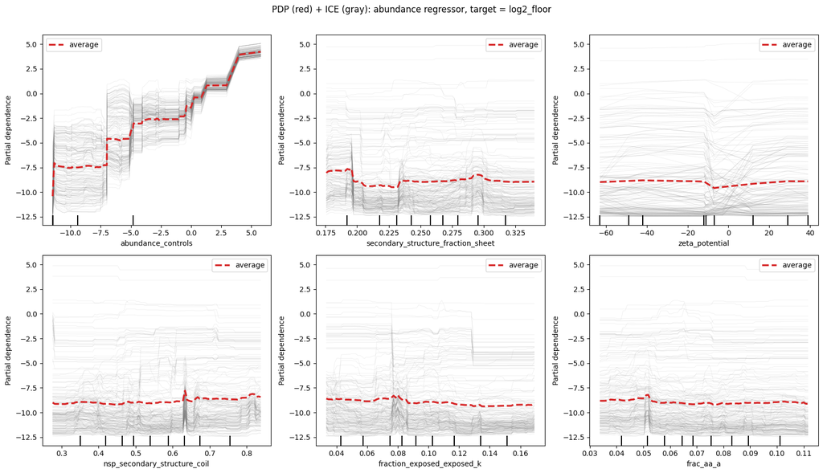

### SHAP. Regression

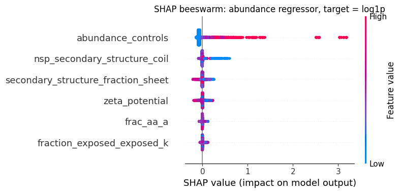

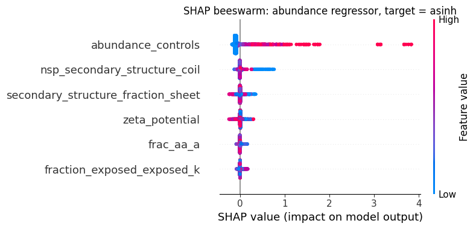

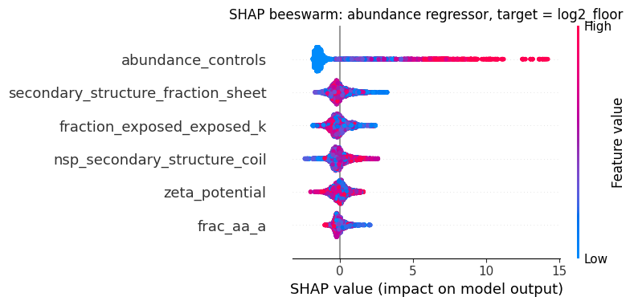

### Protein Clustering. Detection vs Enrichment Response

Per protein, sweep `zeta_potential` over {-60,-40,-20,0,20,40} and record P(class=1), giving a 376x6 response matrix. K-means (k=3) clusters proteins by response-curve shape, for both a detection classifier (`abundance > 0`) and the enrichment classifier. Labels are reordered 0->2 by ascending mean response probability so the two are comparable.

```
response matrices: detect (376, 6), enrich (376, 6)
```

```
Detection clustering:
                  n  mean_prob  zeta_sensitivity
detect_cluster
0               198      0.211             0.322
1                80      0.537             0.467
2                98      0.917             0.101

Enrichment clustering:
                  n  mean_prob  zeta_sensitivity
enrich_cluster
0               218      0.194             0.292
1                73      0.468             0.490
2                85      0.807             0.251
```

```
Adjusted Rand index (detect vs enrich): 0.655
Proteins with the same cluster label:   85.1%  (320/376)

Contingency table (rows = detection cluster, cols = enrichment cluster):
```

| enrich detect | 0 | 1 | 2 |
| --- | --- | --- | --- |
| 0 | 192 | 6 | 0 |
| 1 | 7 | 58 | 15 |
| 2 | 19 | 9 | 70 |

### What Protein Features Define Each Cluster

A protein's cluster is fully determined by its 5 non-zeta `PARSI_6` features. Per-cluster means plus a Kruskal-Wallis test of whether each feature differs across the 3 clusters (small `p_value` = the feature separates clusters), with boxplots of the distributions.

```
Detection clusters -- protein-feature profile:
                                    c0_mean  c1_mean  c2_mean  kruskal_H  \
feature
abundance_controls                 -11.3816 -10.9515  -6.3828   175.2821
secondary_structure_fraction_sheet   0.2631   0.2487   0.2406     7.9642
nsp_secondary_structure_coil         0.5283   0.5902   0.5599    10.7219
fraction_exposed_exposed_k           0.1005   0.0928   0.0915     3.6724
frac_aa_a                            0.0745   0.0681   0.0659     9.9708

                                    p_value
feature
abundance_controls                   0.0000
secondary_structure_fraction_sheet   0.0186
nsp_secondary_structure_coil         0.0047
fraction_exposed_exposed_k           0.1594
frac_aa_a                            0.0068

Enrichment clusters -- protein-feature profile:
                                    c0_mean  c1_mean  c2_mean  kruskal_H  \
feature
abundance_controls                 -10.3527 -10.3209  -8.7633    37.6915
secondary_structure_fraction_sheet   0.2660   0.2353   0.2401    13.9217
nsp_secondary_structure_coil         0.5222   0.5802   0.5940    19.6451
fraction_exposed_exposed_k           0.0993   0.1007   0.0858     7.1871
frac_aa_a                            0.0748   0.0656   0.0655    12.3697

                                    p_value
feature
abundance_controls                   0.0000
secondary_structure_fraction_sheet   0.0009
nsp_secondary_structure_coil         0.0001
fraction_exposed_exposed_k           0.0275
frac_aa_a                            0.0021
```

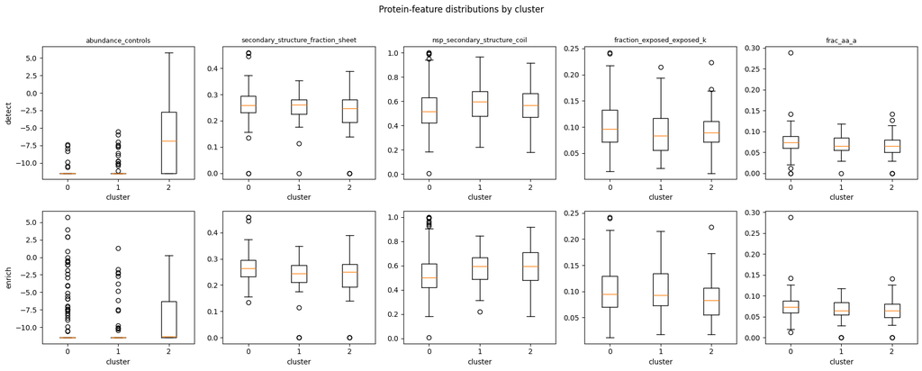

### Full-Feature Clustering Comparison

Repeats the zeta-sweep clustering with classifiers trained on the full 84-feature set, for both targets, then compares each to its `PARSI_6` counterpart via adjusted Rand index and a contingency table. With the full set, other NP features are held fixed at each protein's first-row values during the sweep.

```
Full-feature detection clustering:
                       n  mean_prob  zeta_sensitivity
detect_full_cluster
0                    190      0.173             0.066
1                     91      0.586             0.109
2                     95      0.952             0.017

Full-feature enrichment clustering:
                       n  mean_prob  zeta_sensitivity
enrich_full_cluster
0                    158      0.107             0.046
1                    122      0.416             0.113
2                     96      0.833             0.058
```

```
Does the 6-feature clustering reproduce the full-feature clustering?

parsi6_detect vs full_detect:  ARI = 0.715,  same label = 88.6%
full_detect      0   1   2
parsi6_detect
0              179  19   0
1               11  64   5
2                0   8  90

parsi6_enrich vs full_enrich:  ARI = 0.481,  same label = 76.3%
full_enrich      0   1   2
parsi6_enrich
0              156  60   2
1                2  54  17
2                0   8  77
```

### Proteins That Change Cluster

One table per target, listing proteins whose cluster label differs between the `PARSI_6` and the full-feature clustering (labels are mean-probability-ordered in both).

```
Detection: 43/376 proteins differ between PARSI_6 and full
```

|  | protein_id | parsi6 | full |
| --- | --- | --- | --- |
| 0 | Q3ZBG0 | 0 | 1 |
| 1 | Q3B7N2 | 0 | 1 |
| 2 | P33672 | 0 | 1 |
| 3 | P21793 | 0 | 1 |
| 4 | Q2TA40 | 0 | 1 |
| 5 | O46414 | 0 | 1 |
| 6 | Q3T168 | 0 | 1 |
| 7 | O77742 | 0 | 1 |
| 8 | P80012 | 0 | 1 |
| 9 | Q0VCG9 | 0 | 1 |
| 10 | A6QR46 | 0 | 1 |
| 11 | Q2YDE4 | 0 | 1 |
| 12 | Q5E9K0 | 0 | 1 |
| 13 | P05307 | 0 | 1 |
| 14 | P19427 | 0 | 1 |
| 15 | P55918 | 0 | 1 |
| 16 | Q3ZCK9 | 0 | 1 |
| 17 | Q5E987 | 0 | 1 |
| 18 | Q5KR48 | 0 | 1 |
| 19 | Q2HJ49 | 1 | 0 |
| 20 | Q6Q137 | 1 | 0 |
| 21 | Q27970 | 1 | 0 |
| 22 | Q5E9D5 | 1 | 0 |
| 23 | Q29RU4 | 1 | 0 |
| 24 | P79121 | 1 | 0 |
| 25 | P33046 | 1 | 0 |
| 26 | Q5E9C0 | 1 | 0 |
| 27 | A5D7B7 | 1 | 0 |
| 28 | Q2TA49 | 1 | 0 |
| 29 | F1N152 | 1 | 0 |
| 30 | Q5E9B7 | 1 | 2 |
| 31 | Q5NTB3 | 1 | 2 |
| 32 | Q32LP0 | 1 | 2 |
| 33 | P04815 | 1 | 2 |
| 34 | P07456 | 1 | 2 |
| 35 | Q3T149 | 2 | 1 |
| 36 | P37141 | 2 | 1 |
| 37 | P13608 | 2 | 1 |
| 38 | Q58CQ9 | 2 | 1 |
| 39 | P33433 | 2 | 1 |
| 40 | Q3SZP2 | 2 | 1 |
| 41 | P07507 | 2 | 1 |
| 42 | P00745 | 2 | 1 |

```
Enrichment: 89/376 proteins differ between PARSI_6 and full
```

|  | protein_id | parsi6 | full |
| --- | --- | --- | --- |
| 0 | Q27971 | 0 | 1 |
| 1 | O46415 | 0 | 1 |
| 2 | G3X745 | 0 | 1 |
| 3 | Q3ZBG0 | 0 | 1 |
| 4 | Q3B7N2 | 0 | 1 |
| ... | ... | ... | ... |
| 84 | P21809 | 2 | 1 |
| 85 | A6H767 | 2 | 1 |
| 86 | O18979 | 2 | 1 |
| 87 | Q2KJD0 | 2 | 1 |
| 88 | P81947 | 2 | 1 |

89 rows × 3 columns

|  | entry_id | cluster_detect | cluster_enrich | cluster_detect_full | cluster_enrich_full |
| --- | --- | --- | --- | --- | --- |
| 0 | Q3T149 | 2 | 2 | 1 | 2 |
| 1 | Q3T0A3 | 1 | 1 | 1 | 1 |
| 2 | Q2KJ33 | 1 | 1 | 1 | 1 |
| 3 | P39873 | 1 | 1 | 1 | 1 |
| 4 | Q27971 | 0 | 0 | 0 | 1 |

## Export Intermediate Tables

Write every result table to `data/` (created next to this notebook) as a CSV with no index column. Run after all analysis cells above.

```
  rfr_bootstrap_importance.csv                       84 x 5
  rfr_bootstrap_importance_raw.csv                  500 x 85
  rfc_bootstrap_importance.csv                       84 x 5
  rfc_bootstrap_importance_raw.csv                  500 x 85
  rfr_top10_feature_correlation.csv                  10 x 11
  rfecv_regression_cv_scores.csv                     84 x 3
  rfecv_regression_feature_ranking.csv               84 x 4
  classifier_permutation_importance.csv              84 x 5
  rfecv_classifier_cv_scores.csv                     84 x 3
  rfecv_classifier_selected_features.csv             26 x 3
  rfecv_classifier_feature_set_oof_metrics.csv        3 x 8
  parsimonious6_feature_correlation.csv               6 x 7
  parsimonious_classifier_oof_metrics.csv             3 x 8
  parsimonious_regression_loo_metrics.csv             9 x 9
  cluster_summary_parsimonious6.csv                   6 x 5
  cluster_summary_full84.csv                          6 x 5
  cluster_feature_profile.csv                        10 x 7
  protein_clusters.csv                              376 x 5
  cluster_label_diff_detection.csv                   43 x 3
  cluster_label_diff_enrichment.csv                  89 x 3
  shap_clf_parsi6_values.csv                       6768 x 6
  shap_clf_parsi6_data.csv                         6768 x 6
  shap_reg_parsi6_log1p_values.csv                 6768 x 6
  shap_reg_parsi6_log1p_data.csv                   6768 x 6
```

```
  shap_reg_parsi6_asinh_values.csv                 6768 x 6
```

```
  shap_reg_parsi6_asinh_data.csv                   6768 x 6
  shap_reg_parsi6_log2_floor_values.csv            6768 x 6
  shap_reg_parsi6_log2_floor_data.csv              6768 x 6
```

```
  shap_rfr_full84_log1p_values.csv                 6768 x 84
```

```
  shap_rfr_full84_log1p_data.csv                   6768 x 84
```

```
  shap_rfr_full84_asinh_values.csv                 6768 x 84
```

```
  shap_rfr_full84_asinh_data.csv                   6768 x 84
```

```
  shap_rfr_full84_log2_floor_values.csv            6768 x 84
```

```
  shap_rfr_full84_log2_floor_data.csv              6768 x 84
```